# MUSE – Bring Future To Talk To Legacy

Ambarish Ganguly

# 1 Introduction

# 2 Read the Data

```r
library(tidyverse)
library(lubridate)
library(forecast)
library(DT)


rm(list=ls())

fillColor = "#FFA07A"
fillColor2 = "#F1C40F"

BusyTransactions_dump <- tibble(text = read_lines("../input/BUSY7246fb6.csv", skip = 1))

BusyTransactions <- BusyTransactions_dump %>%
  separate(text, into = c("POS_Application_Name",
                          "STOREID",
                          "MACID",
                          "BILLNO",
                          "BARCODE",
                          "GUID",
                          "CREATED_STAMP",
                          "CAPTURED_WINDOW",
                          "UPDATE_STAMP"), sep = "\\|")

rm(BusyTransactions_dump)

EasySOLTransactions_dump <- tibble(text = read_lines("../input/EASYSOL326dc49.csv", skip = 1))

EasySOLTransactions <- EasySOLTransactions_dump %>%
  separate(text, into = c("POS_Application_Name",
                          "STOREID",
                          "MACID",
                          "BILLNO",
                          "BARCODE",
                          "GUID",
                          "CREATED_STAMP",
                          "CAPTURED_WINDOW",
                          "UPDATE_STAMP"), sep = "\\|")
rm(EasySOLTransactions_dump)

MargTransactions_dump <- tibble(text = read_lines("../input/MARGfc72cd7.csv", skip = 1))

#POS_Application_Name|STOREID|MACID|BILLNO|BARCODE|GUID|CREATED_STAMP|CAPTURED_WINDOW|UPDATE_STAMP

MargTransactions <- MargTransactions_dump %>%
  separate(text, into = c("POS_Application_Name",
                          "STOREID",
                          "MACID",
                          "BILLNO",
                          "BARCODE",
                          "GUID",
                          "CREATED_STAMP",
                          "CAPTURED_WINDOW",
                          "UPDATE_STAMP"), sep = "\\|")

rm(MargTransactions_dump)

RetailExPerTransactions_dump <- tibble(text = read_lines("../input/RETAIL_EXPERe490dde.csv", skip = 1))

#POS_Application_Name|STOREID|MACID|BILLNO|BARCODE|GUID|CREATED_STAMP|CAPTURED_WINDOW|UPDATE_STAMP

RetailExPerTransactions <- RetailExPerTransactions_dump %>%
  separate(text, into = c("POS_Application_Name",
                          "STOREID",
                          "MACID",
                          "BILLNO",
                          "BARCODE",
                          "GUID",
                          "CREATED_STAMP",
                          "CAPTURED_WINDOW",
                          "UPDATE_STAMP"), sep = "\\|")

rm(RetailExPerTransactions_dump)

SoftGenTransactions_dump <- tibble(text = read_lines("../input/SOFT_GENd6661f5.csv", skip = 1))

#POS_Application_Name|STOREID|MACID|BILLNO|BARCODE|GUID|CREATED_STAMP|CAPTURED_WINDOW|UPDATE_STAMP

SoftGenTransactions <- SoftGenTransactions_dump %>%
  separate(text, into = c("POS_Application_Name",
                          "STOREID",
                          "MACID",
                          "BILLNO",
                          "BARCODE",
                          "GUID",
                          "CREATED_STAMP",
                          "CAPTURED_WINDOW",
                          "UPDATE_STAMP"), sep = "\\|")

rm(SoftGenTransactions_dump)

AllTransactions =  rbind(BusyTransactions,EasySOLTransactions,MargTransactions,
                         RetailExPerTransactions,SoftGenTransactions)


ProductMaster = read.csv(file="../input/ProductMaster404b8b3.csv",stringsAsFactors = FALSE)

ProductMasterDistinct = ProductMaster %>% distinct()
```

# 3 Top 10 Brands Sold in the Stores

The following plot displays the Top 10 Brands sold in the Stores.

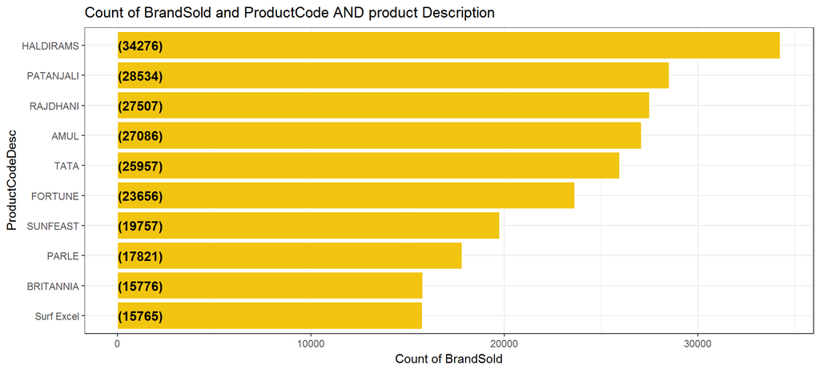

```r
AllItems = AllTransactions %>%
  left_join(ProductMasterDistinct) %>%
  filter(BRAND_DESC != "NULL") %>%
  filter(BRAND_DESC != "Unknown") %>%
  group_by(BRAND_DESC) %>%
  tally() %>%
  arrange(desc(n))


AllItems %>%
  ungroup() %>%
  head(10) %>%
  mutate(ProductCodeDesc = paste0(BRAND_DESC)) %>%
  mutate(ProductCodeDesc = reorder(ProductCodeDesc,n))  %>%
  ggplot(aes(x = ProductCodeDesc,y = n)) +
  geom_bar(stat='identity',colour="white", fill =fillColor2) +
  geom_text(aes(x = ProductCodeDesc, y = 1, label = paste0("(",n,")",sep="")),
            hjust=0, vjust=.5, size = 4, colour = 'black',
            fontface = 'bold') +
  labs(x = 'ProductCodeDesc', y = 'Count of BrandSold',
       title = 'Count of BrandSold and ProductCode AND product Description') +
  coord_flip() +
  theme_bw()
```

# 4 Top 10 Brands With Company Code Sold in the Stores

The following plot displays the Top 10 Brands sold in the Stores.

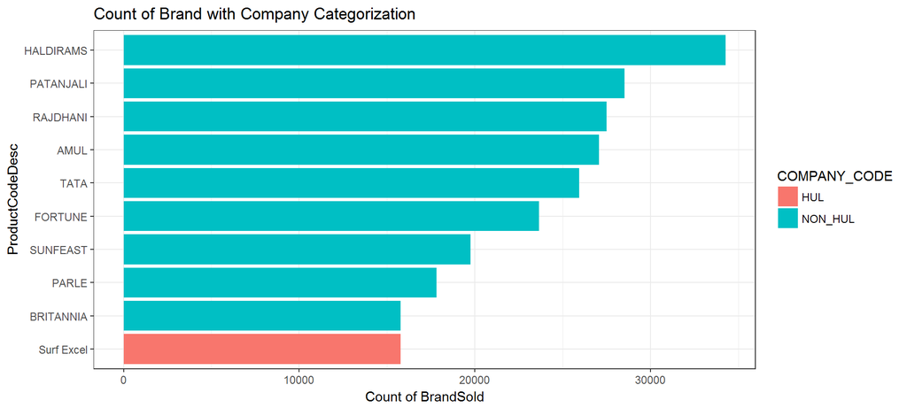

```r
AllItems = AllTransactions %>%
  left_join(ProductMasterDistinct) %>%
  filter(BRAND_DESC != "NULL") %>%
  filter(BRAND_DESC != "Unknown") %>%
  group_by(BRAND_DESC,COMPANY_CODE) %>%
  tally() %>%
  arrange(desc(n))

AllItems = AllItems %>%
  mutate(COMPANY_CODE = ifelse(COMPANY_CODE == "", "NON_HUL",  COMPANY_CODE) )

AllItems %>%
  ungroup() %>%
  head(10) %>%
  mutate(ProductCodeDesc = paste0(BRAND_DESC)) %>%
  mutate(ProductCodeDesc = reorder(ProductCodeDesc,n))  %>%
  ggplot(aes(x = ProductCodeDesc,y = n,fill =COMPANY_CODE)) +
  geom_bar(stat='identity') +
  labs(x = 'ProductCodeDesc', y = 'Count of BrandSold',
       title = 'Count of Brand with Company Categorization') +
  coord_flip() +
  theme_bw()
```

# 5 Top 10 Hindustan UniLever Brands Sold in the Stores

The following plot displays the Top 10 Hindustan UniLever Brands sold in the Stores.We observe that the following Brandappear in the Top 10 list

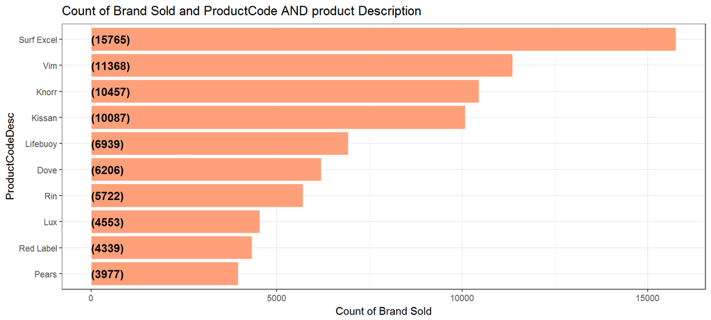

```r
AllItems = AllTransactions %>%
  left_join(ProductMasterDistinct) %>%
  filter(COMPANY_CODE == "HUL") %>%

  group_by(BRAND_DESC) %>%
  tally() %>%
  arrange(desc(n))

AllItemsTop = AllItems %>%
  ungroup() %>%
  head(10) %>%
  mutate(ProductCodeDesc = BRAND_DESC) %>%
  mutate(ProductCodeDesc = reorder(ProductCodeDesc,n))

AllItemsTop %>%
  ggplot(aes(x = ProductCodeDesc,y = n)) +
  geom_bar(stat='identity',colour="white", fill =fillColor) +
  geom_text(aes(x = ProductCodeDesc, y = 1, label = paste0("(",n,")",sep="")),
            hjust=0, vjust=.5, size = 4, colour = 'black',
            fontface = 'bold') +
  labs(x = 'ProductCodeDesc', y = 'Count of Brand Sold',
       title = 'Count of Brand Sold and ProductCode AND product Description') +
  coord_flip() +
  theme_bw()
```

# 6 Top 10 SubCategories Sold in the Stores

The following plot displays the Top 10 SubCategories sold in the Stores.

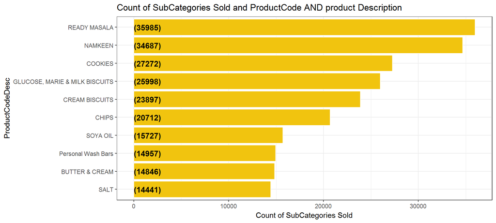

```r
AllItems = AllTransactions %>%
  left_join(ProductMasterDistinct) %>%
  filter(SUBCATEGORY_DESC != "NULL") %>%
  filter(SUBCATEGORY_DESC != "Unknown") %>%
  group_by(SUBCATEGORY_DESC,COMPANY_CODE) %>%
  tally() %>%
  arrange(desc(n))


AllItems %>%
  ungroup() %>%
  head(10) %>%
  mutate(ProductCodeDesc = paste0(SUBCATEGORY_DESC)) %>%
  mutate(ProductCodeDesc = reorder(ProductCodeDesc,n))  %>%
  ggplot(aes(x = ProductCodeDesc,y = n)) +
  geom_bar(stat='identity',colour="white", fill =fillColor2) +
  geom_text(aes(x = ProductCodeDesc, y = 1, label = paste0("(",n,")",sep="")),
            hjust=0, vjust=.5, size = 4, colour = 'black',
            fontface = 'bold') +
  labs(x = 'ProductCodeDesc', y = 'Count of SubCategories Sold',
       title = 'Count of SubCategories Sold and ProductCode AND product Description') +
  coord_flip() +
  theme_bw()
```

# 7 Top 10 Hindustan UniLever SubCategories Sold in the Stores

The following plot displays the Top 10 Hindustan UniLever SubCategories sold in the Stores.We observe that the following SubCategories appear in the Top 10 list

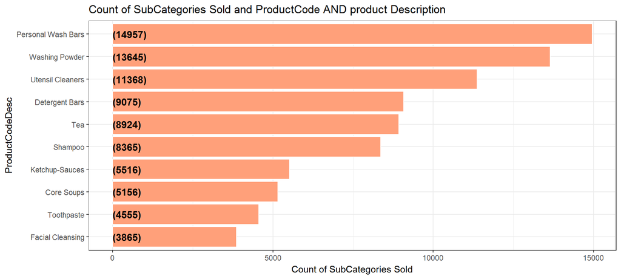

```r
AllItems = AllTransactions %>%
  left_join(ProductMasterDistinct) %>%
  filter(COMPANY_CODE == "HUL") %>%

  group_by(SUBCATEGORY_DESC) %>%
  tally() %>%
  arrange(desc(n))

AllItemsTop = AllItems %>%
  ungroup() %>%
  head(10) %>%
  mutate(ProductCodeDesc = SUBCATEGORY_DESC) %>%
  mutate(ProductCodeDesc = reorder(ProductCodeDesc,n))

AllItemsTop %>%
  ggplot(aes(x = ProductCodeDesc,y = n)) +
  geom_bar(stat='identity',colour="white", fill =fillColor) +
  geom_text(aes(x = ProductCodeDesc, y = 1, label = paste0("(",n,")",sep="")),
            hjust=0, vjust=.5, size = 4, colour = 'black',
            fontface = 'bold') +
  labs(x = 'ProductCodeDesc', y = 'Count of SubCategories Sold',
       title = 'Count of SubCategories Sold and ProductCode AND product Description') +
  coord_flip() +
  theme_bw()
```

# 8 Market Basket Analysis of Subcategories

## 8.1 Top 10 Sub Categories sold with READY MASALA

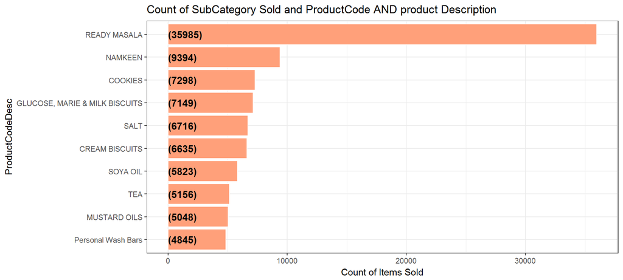

```r
AllItems_TopProduct_1_BILLNO =
  AllTransactions %>%
  left_join(ProductMasterDistinct) %>%
  filter(SUBCATEGORY_DESC != "NULL") %>%
  filter(SUBCATEGORY_DESC != "Unknown") %>%
  filter(SUBCATEGORY_DESC == "READY MASALA") %>%
  select(BILLNO) %>%
  distinct()

AllItems_WithTopProduct_1 = AllTransactions %>%
  filter(BILLNO %in% AllItems_TopProduct_1_BILLNO$BILLNO )

#Get all Items which are Sold With TopProduct_1
AllItems_WithTopProduct_1Desc = AllItems_WithTopProduct_1 %>%
  left_join(ProductMasterDistinct) %>%
  filter(SUBCATEGORY_DESC != "Unknown") %>%
  group_by(SUBCATEGORY_DESC) %>%
  tally() %>%
  arrange(desc(n))


AllItems_WithTopProduct_1Desc %>%
  ungroup() %>%
  filter(SUBCATEGORY_DESC != "NULL") %>%
  filter(SUBCATEGORY_DESC != "OTHERS") %>%
  head(10) %>%
  mutate(ProductCodeDesc = paste0(SUBCATEGORY_DESC)) %>%
  mutate(ProductCodeDesc = reorder(ProductCodeDesc,n))  %>%
  ggplot(aes(x = ProductCodeDesc,y = n)) +
  geom_bar(stat='identity',colour="white", fill =fillColor) +
  geom_text(aes(x = ProductCodeDesc, y = 1, label = paste0("(",n,")",sep="")),
            hjust=0, vjust=.5, size = 4, colour = 'black',
            fontface = 'bold') +
  labs(x = 'ProductCodeDesc', y = 'Count of Items Sold',
       title = 'Count of SubCategory Sold and ProductCode AND product Description') +
  coord_flip() +
  theme_bw()
```

# 9 Top 10 Items Sold in the Stores

The following plot displays the Top 10 items sold in the Stores.

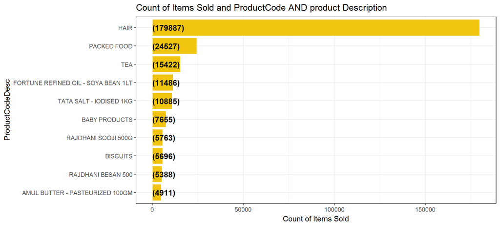

```r
AllItems = AllTransactions %>%
  left_join(ProductMasterDistinct) %>%
  filter(BASEPACK_DESC != "NA") %>%
  filter(BASEPACK_DESC != "OTHERS") %>%
  filter(BASEPACK_DESC != "Unknown") %>%
  group_by(BASEPACK_DESC) %>%
  tally() %>%
  arrange(desc(n))


AllItems %>%
  ungroup() %>%
  head(10) %>%
  mutate(ProductCodeDesc = paste0(BASEPACK_DESC)) %>%
  mutate(ProductCodeDesc = reorder(ProductCodeDesc,n))  %>%
  ggplot(aes(x = ProductCodeDesc,y = n)) +
  geom_bar(stat='identity',colour="white", fill =fillColor2) +
  geom_text(aes(x = ProductCodeDesc, y = 1, label = paste0("(",n,")",sep="")),
            hjust=0, vjust=.5, size = 4, colour = 'black',
            fontface = 'bold') +
  labs(x = 'ProductCodeDesc', y = 'Count of Items Sold',
       title = 'Count of Items Sold and ProductCode AND product Description') +
  coord_flip() +
  theme_bw()
```

# 10 Top 10 Hindustan UniLever Items Sold in the Stores

The following plot displays the Top 10 Hindustan UniLever items sold in the Stores.We observe that the following items appear in the Top 10 list

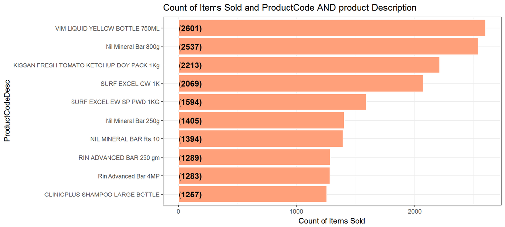

```r
AllItems = AllTransactions %>%
  left_join(ProductMasterDistinct) %>%
  filter(COMPANY_CODE == "HUL") %>%

  group_by(BASEPACK_DESC) %>%
  tally() %>%
  arrange(desc(n))

AllItemsTop = AllItems %>%
  ungroup() %>%
  head(10) %>%
  mutate(ProductCodeDesc = BASEPACK_DESC) %>%
  mutate(ProductCodeDesc = reorder(ProductCodeDesc,n))

AllItemsTop %>%
  ggplot(aes(x = ProductCodeDesc,y = n)) +
  geom_bar(stat='identity',colour="white", fill =fillColor) +
  geom_text(aes(x = ProductCodeDesc, y = 1, label = paste0("(",n,")",sep="")),
            hjust=0, vjust=.5, size = 4, colour = 'black',
            fontface = 'bold') +
  labs(x = 'ProductCodeDesc', y = 'Count of Items Sold',
       title = 'Count of Items Sold and ProductCode AND product Description') +
  coord_flip() +
  theme_bw()
```

# 11 Top 10 NON Hindustan UniLever Items Sold in the Stores

We investigate the Top Ten NON Hindustan UniLever Items Sold in the Stores. Products involving Face, Tea, Oil , Water and Soap feature among the most popular items.

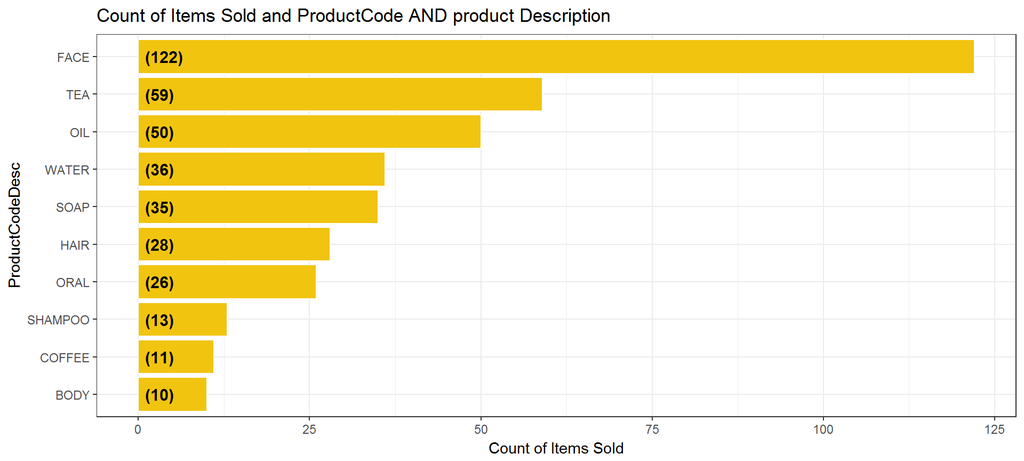

```r
AllItems = AllTransactions %>%
  left_join(ProductMasterDistinct) %>%
  filter(COMPANY_CODE == "NON_HUL") %>%

  group_by(BASEPACK_DESC) %>%
  tally() %>%
  arrange(desc(n))

AllItems %>%
  ungroup() %>%
  head(10) %>%
  mutate(ProductCodeDesc = paste0(BASEPACK_DESC)) %>%
  mutate(ProductCodeDesc = reorder(ProductCodeDesc,n))  %>%
  ggplot(aes(x = ProductCodeDesc,y = n)) +
  geom_bar(stat='identity',colour="white", fill =fillColor2) +
  geom_text(aes(x = ProductCodeDesc, y = 1, label = paste0("(",n,")",sep="")),
            hjust=0, vjust=.5, size = 4, colour = 'black',
            fontface = 'bold') +
  labs(x = 'ProductCodeDesc', y = 'Count of Items Sold',
       title = 'Count of Items Sold and ProductCode AND product Description') +
  coord_flip() +
  theme_bw()
```

# 12 Market Basket Analysis of Items

## 12.1 Top 10 Items sold with VIM LIQUID YELLOW BOTTLE 750 ML

**VIM LIQUID YELLOW BOTTLE 750 ML** is the MOST **Popular** HUL product. We wish to examine the products which have been bought with **VIM LIQUID YELLOW BOTTLE 750 ML**. We observe the followng products are bought with VIM LIQUID YELLOW BOTTLE 750 ML

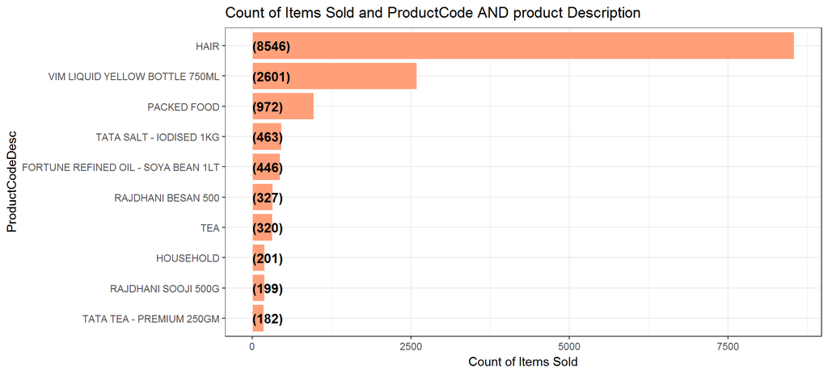

```r
AllItems_TopProduct_1_BILLNO =
  AllTransactions %>%
  left_join(ProductMasterDistinct) %>%
  filter(BASEPACK_DESC != "Unknown") %>%
  filter(BASEPACK_DESC == "VIM LIQUID YELLOW BOTTLE 750ML") %>%
  select(BILLNO) %>%
  distinct()

AllItems_WithTopProduct_1 = AllTransactions %>%
  filter(BILLNO %in% AllItems_TopProduct_1_BILLNO$BILLNO )

#Get all Items which are Sold With TopProduct_1
AllItems_WithTopProduct_1Desc = AllItems_WithTopProduct_1 %>%
  left_join(ProductMasterDistinct) %>%
  filter(BASEPACK_DESC != "Unknown") %>%
  group_by(BASEPACK_DESC) %>%
  tally() %>%
  arrange(desc(n))


AllItems_WithTopProduct_1Desc %>%
  ungroup() %>%
  filter(BASEPACK_DESC != "OTHERS") %>%
  head(10) %>%
  mutate(ProductCodeDesc = paste0(BASEPACK_DESC)) %>%
  mutate(ProductCodeDesc = reorder(ProductCodeDesc,n))  %>%
  ggplot(aes(x = ProductCodeDesc,y = n)) +
  geom_bar(stat='identity',colour="white", fill =fillColor) +
  geom_text(aes(x = ProductCodeDesc, y = 1, label = paste0("(",n,")",sep="")),
            hjust=0, vjust=.5, size = 4, colour = 'black',
            fontface = 'bold') +
  labs(x = 'ProductCodeDesc', y = 'Count of Items Sold',
       title = 'Count of Items Sold and ProductCode AND product Description') +
  coord_flip() +
  theme_bw()
```

## 12.2 Top 10 Hindustan UniLever Items sold with VIM LIQUID YELLOW BOTTLE 750 ML

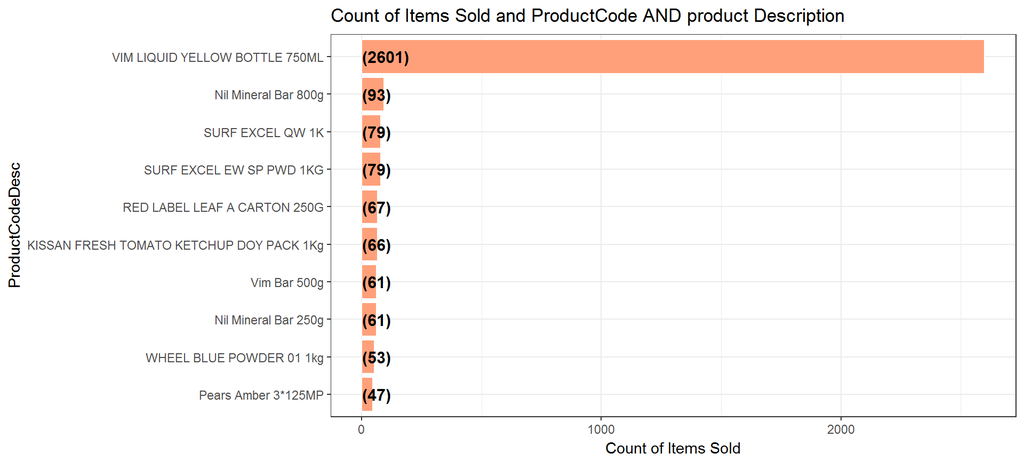

```r
AllItems_TopProduct_1_BILLNO =
  AllTransactions %>%
  left_join(ProductMasterDistinct) %>%
  filter(COMPANY_CODE == "HUL") %>%
  filter(BASEPACK_DESC != "NA") %>%
  filter(BASEPACK_DESC != "OTHERS") %>%
  filter(BASEPACK_DESC != "Unknown") %>%
  filter(BASEPACK_DESC == "VIM LIQUID YELLOW BOTTLE 750ML") %>%
  select(BILLNO) %>%
  distinct()

AllItems_WithTopProduct_1 = AllTransactions %>%
  filter(BILLNO %in% AllItems_TopProduct_1_BILLNO$BILLNO )

#Get all Items which are Sold With TopProduct_1
AllItems_WithTopProduct_1Desc = AllItems_WithTopProduct_1 %>%
  left_join(ProductMasterDistinct) %>%
  filter(COMPANY_CODE == "HUL") %>%
  filter(BASEPACK_DESC != "NA") %>%
  filter(BASEPACK_DESC != "OTHERS") %>%
  filter(BASEPACK_DESC != "Unknown") %>%
  group_by(BASEPACK_DESC) %>%
  tally() %>%
  arrange(desc(n))


AllItems_WithTopProduct_1Desc %>%
  ungroup() %>%
   head(10) %>%
  mutate(ProductCodeDesc = paste0(BASEPACK_DESC)) %>%
  mutate(ProductCodeDesc = reorder(ProductCodeDesc,n))  %>%
  ggplot(aes(x = ProductCodeDesc,y = n)) +
  geom_bar(stat='identity',colour="white", fill =fillColor) +
  geom_text(aes(x = ProductCodeDesc, y = 1, label = paste0("(",n,")",sep="")),
            hjust=0, vjust=.5, size = 4, colour = 'black',
            fontface = 'bold') +
  labs(x = 'ProductCodeDesc', y = 'Count of Items Sold',
       title = 'Count of Items Sold and ProductCode AND product Description') +
  coord_flip() +
  theme_bw()
```

## 12.3 Top 10 Items sold with Nil Mineral Bar 800g

We wish to examine the products which have been bought with **Nil Mineral Bar 800g**. We observe the followng products are bought with Nil Mineral Bar 800g

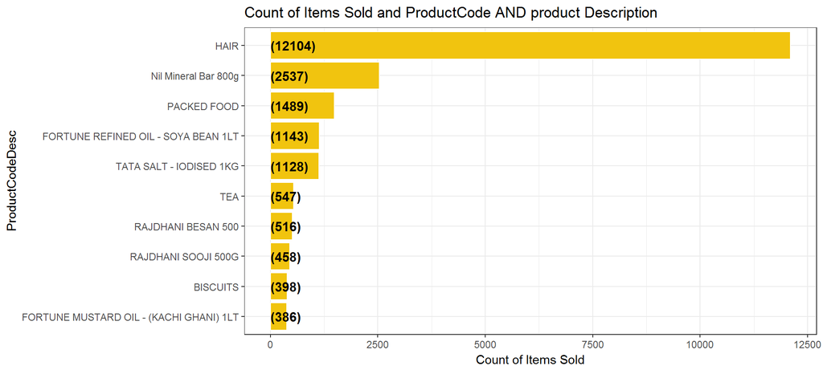

```r
AllItems_TopProduct_1_BILLNO =
  AllTransactions %>%
  left_join(ProductMasterDistinct) %>%
  filter(BASEPACK_DESC == "Nil Mineral Bar 800g") %>%
  select(BILLNO) %>%
  distinct()

AllItems_WithTopProduct_1 = AllTransactions %>%
  filter(BILLNO %in% AllItems_TopProduct_1_BILLNO$BILLNO )

#Get all Items which are Sold With TopProduct_1
AllItems_WithTopProduct_1Desc = AllItems_WithTopProduct_1 %>%
  left_join(ProductMasterDistinct) %>%
  filter(BASEPACK_DESC != "NA") %>%
  filter(BASEPACK_DESC != "OTHERS") %>%
  filter(BASEPACK_DESC != "Unknown") %>%
  group_by(BASEPACK_DESC) %>%
  tally() %>%
  arrange(desc(n))


AllItems_WithTopProduct_1Desc %>%
  ungroup() %>%
  filter(BASEPACK_DESC != "OTHERS") %>%
  head(10) %>%
  mutate(ProductCodeDesc = paste0(BASEPACK_DESC)) %>%
  mutate(ProductCodeDesc = reorder(ProductCodeDesc,n))  %>%
  ggplot(aes(x = ProductCodeDesc,y = n)) +
  geom_bar(stat='identity',colour="white", fill =fillColor2) +
  geom_text(aes(x = ProductCodeDesc, y = 1, label = paste0("(",n,")",sep="")),
            hjust=0, vjust=.5, size = 4, colour = 'black',
            fontface = 'bold') +
  labs(x = 'ProductCodeDesc', y = 'Count of Items Sold',
       title = 'Count of Items Sold and ProductCode AND product Description') +
  coord_flip() +
  theme_bw()
```

## 12.4 Top 10 Hindustan UniLever Items sold with Nil Mineral Bar 800g

We wish to examine the Hindustan UniLever products which have been bought with **Nil Mineral Bar 800g**. We observe the followng products are bought with Nil Mineral Bar 800g

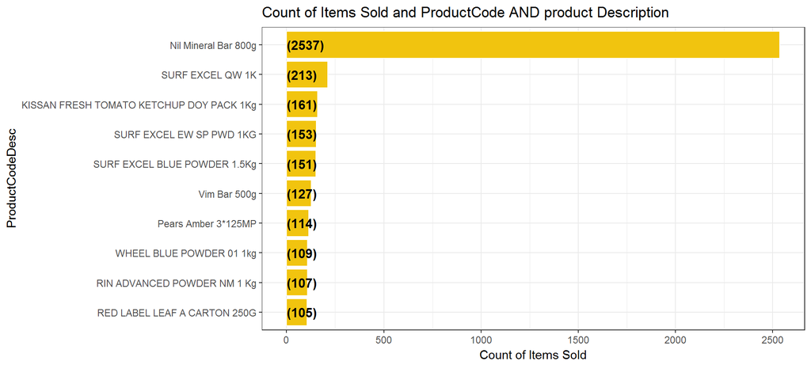

```r
AllItems_TopProduct_1_BILLNO =
  AllTransactions %>%
  left_join(ProductMasterDistinct) %>%
  filter(COMPANY_CODE == "HUL") %>%
  filter(BASEPACK_DESC != "NA") %>%
  filter(BASEPACK_DESC != "OTHERS") %>%
  filter(BASEPACK_DESC != "Unknown") %>%
  filter(BASEPACK_DESC == "Nil Mineral Bar 800g") %>%
  select(BILLNO) %>%
  distinct()

AllItems_WithTopProduct_1 = AllTransactions %>%
  filter(BILLNO %in% AllItems_TopProduct_1_BILLNO$BILLNO )

#Get all Items which are Sold With TopProduct_1
AllItems_WithTopProduct_1Desc = AllItems_WithTopProduct_1 %>%
  left_join(ProductMasterDistinct) %>%
  filter(BASEPACK_DESC != "NA") %>%
  filter(BASEPACK_DESC != "OTHERS") %>%
  filter(BASEPACK_DESC != "Unknown") %>%
  filter(COMPANY_CODE == "HUL") %>%
  group_by(BASEPACK_DESC) %>%
  tally() %>%
  arrange(desc(n))


AllItems_WithTopProduct_1Desc %>%
  ungroup() %>%
  head(10) %>%
  mutate(ProductCodeDesc = paste0(BASEPACK_DESC)) %>%
  mutate(ProductCodeDesc = reorder(ProductCodeDesc,n))  %>%
  ggplot(aes(x = ProductCodeDesc,y = n)) +
  geom_bar(stat='identity',colour="white", fill =fillColor2) +
  geom_text(aes(x = ProductCodeDesc, y = 1, label = paste0("(",n,")",sep="")),
            hjust=0, vjust=.5, size = 4, colour = 'black',
            fontface = 'bold') +
  labs(x = 'ProductCodeDesc', y = 'Count of Items Sold',
       title = 'Count of Items Sold and ProductCode AND product Description') +
  coord_flip() +
  theme_bw()
```

# 13 Top Stores selling the MOST goods

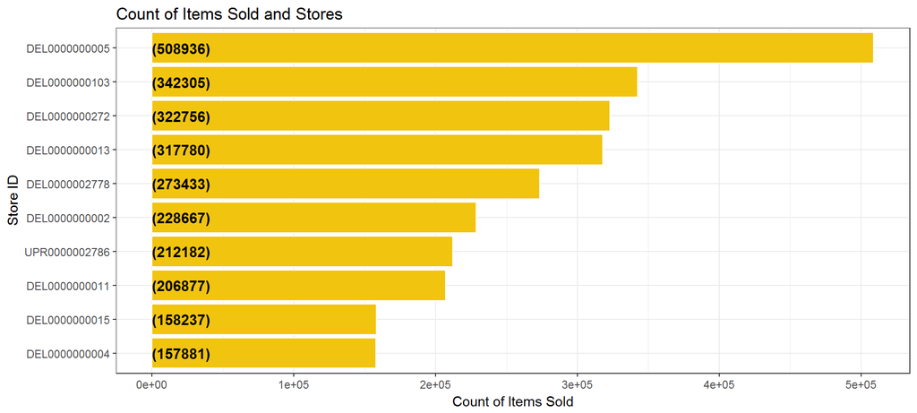

```r
AllTransactions %>%
  group_by(STOREID) %>%
  tally() %>%
  arrange(desc(n)) %>%
  head(10) %>%
  ungroup() %>%
  mutate(STOREID = reorder(STOREID,n))  %>%

  ggplot(aes(x = STOREID,y = n)) +
  geom_bar(stat='identity',colour="white", fill =fillColor2) +
  geom_text(aes(x = STOREID, y = 1, label = paste0("(",n,")",sep="")),
            hjust=0, vjust=.5, size = 4, colour = 'black',
            fontface = 'bold') +
  labs(x = 'Store ID', y = 'Count of Items Sold',
       title = 'Count of Items Sold and Stores') +
  coord_flip() +
  theme_bw()
```

# 14 Stores selling the LEAST goods

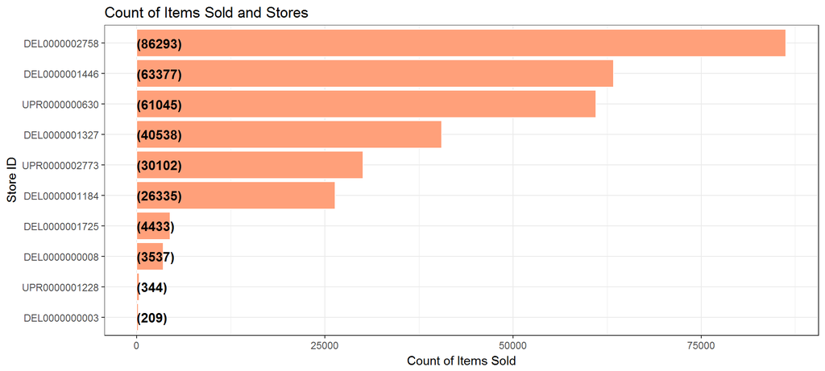

```r
AllTransactions %>%
  group_by(STOREID) %>%
  tally() %>%
  arrange(desc(n)) %>%
  tail(10) %>%
  ungroup() %>%
  mutate(STOREID = reorder(STOREID,n))  %>%

  ggplot(aes(x = STOREID,y = n)) +
  geom_bar(stat='identity',colour="white", fill =fillColor) +
  geom_text(aes(x = STOREID, y = 1, label = paste0("(",n,")",sep="")),
            hjust=0, vjust=.5, size = 4, colour = 'black',
            fontface = 'bold') +
  labs(x = 'Store ID', y = 'Count of Items Sold',
       title = 'Count of Items Sold and Stores') +
  coord_flip() +
  theme_bw()
```

# 15 Perform Date Manipulations

```r
#Week
AllTransactions$CREATED_STAMP = as.Date(AllTransactions$CREATED_STAMP)

AllTransactions$CREATED_STAMP_Week = week(ymd(AllTransactions$CREATED_STAMP))
```

# 16 Trend of Sales of Nil Mineral Bar 800g

The trend of sales of **Nil Mineral Bar 800g** is being shown.

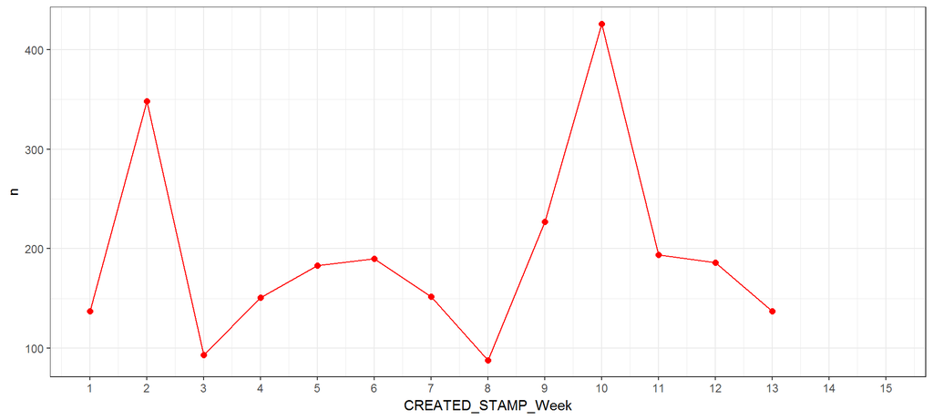

```r
AllItems_TopProduct_1_Week =
  AllTransactions %>%
  filter(BARCODE == "8901030341663") %>%
  group_by(CREATED_STAMP_Week) %>%
  tally()

breaks = seq(1,15,1)

AllItems_TopProduct_1_Week %>%
  ggplot(aes(x=CREATED_STAMP_Week,y=n)) +

  scale_x_continuous(limits = c(1, 15),breaks=breaks ) +

  geom_line(size=.5, color="red")+geom_point(size=2, color="red")+theme_bw()
```

# 17 Trend of Sales of KISSAN FRESH TOMATO KETCHUP DOY PACK 1Kg

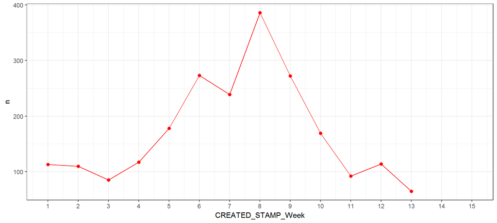

```r
AllItems_TopProduct_1_Week =
  AllTransactions %>%
  filter(BARCODE == "8901030534898") %>%
  group_by(CREATED_STAMP_Week) %>%
  tally()

breaks = seq(1,15,1)

AllItems_TopProduct_1_Week %>%
  ggplot(aes(x=CREATED_STAMP_Week,y=n)) +

  scale_x_continuous(limits = c(1, 15),breaks=breaks ) +

  geom_line(size=.5, color="red")+geom_point(size=2, color="red")+theme_bw()
```

The sales jump in the weeks **6 and 8**.

# 18 Top 10 Hindustan Lever Items Sold in the Store DEL0000000005

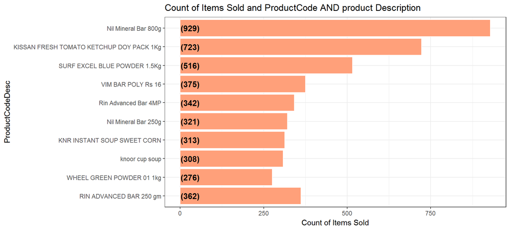

```r
AllItemsTopDELX = AllTransactions %>%
  filter(STOREID == "DEL0000000005")  %>%
  group_by(BARCODE) %>%
  tally() %>%
  arrange(desc(n)) %>%
  left_join(ProductMasterDistinct)  %>%
  mutate(ProductCodeDesc = BASEPACK_DESC) %>%
  mutate(ProductCodeDesc = reorder(ProductCodeDesc,n))

AllItemsTopDELX %>%
  filter(COMPANY_CODE == "HUL") %>%
  head(10) %>%
  ggplot(aes(x = ProductCodeDesc,y = n)) +
  geom_bar(stat='identity',colour="white", fill =fillColor) +
  geom_text(aes(x = ProductCodeDesc, y = 1, label = paste0("(",n,")",sep="")),
            hjust=0, vjust=.5, size = 4, colour = 'black',
            fontface = 'bold') +
  labs(x = 'ProductCodeDesc', y = 'Count of Items Sold',
       title = 'Count of Items Sold and ProductCode AND product Description') +
  coord_flip() +
  theme_bw()
```

# 19 Trend of Sales of Nil Mineral Bar 800g sold in DEL0000000005

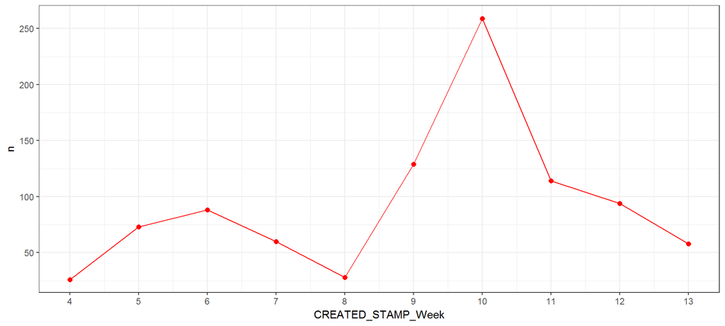

```r
AllItems_TopProduct_1_WeekDELX =
  AllTransactions %>%
  filter(BARCODE == "8901030341663") %>%
  filter(STOREID == "DEL0000000005")  %>%
  group_by(CREATED_STAMP_Week) %>%
  tally()

breaks = seq(1,15,1)

AllItems_TopProduct_1_WeekDELX %>%
  ggplot(aes(x=CREATED_STAMP_Week,y=n)) +
  scale_x_continuous(limits = c(4, 13),breaks=breaks ) +
  geom_line(size=.5, color="red")+geom_point(size=2, color="red")+theme_bw()
```

# 20 Forecasting of Nil Mineral Bar 800g sold in DEL0000000005

## 20.1 Forecasting using ARIMA

The forecasting of the product is done through ARIMA (Autoregressive integrated moving average method)

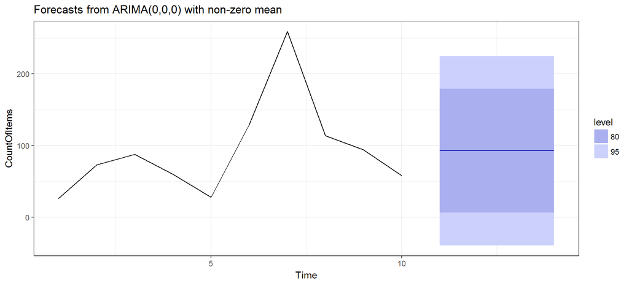

```r
CountOfItems = ts(AllItems_TopProduct_1_WeekDELX$n)

fit = auto.arima(CountOfItems,stepwise=FALSE, approximation=FALSE)

predictions = fit %>% forecast(h=4)

predictions %>% autoplot(include=10) +theme_bw()
```

The predictions for Weeks 14, 15, 16 and 17 using ARIMA are shown here.

|  | Weeks | Predictions |
| --- | --- | --- |
| 1 | Week 14 | 93 |
| 2 | Week 15 | 93 |
| 3 | Week 16 | 93 |
| 4 | Week 17 | 93 |

## 20.2 Forecasting using ETS

The forecasting of the product is done through ETS (Exponential Time Series)

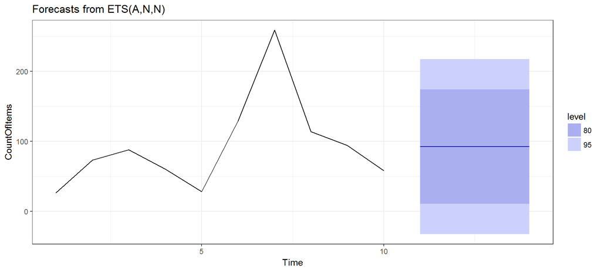

```r
CountOfItems = ts(AllItems_TopProduct_1_WeekDELX$n)

fit = ets(CountOfItems)

predictions = fit %>% forecast(h=4)

predictions %>% autoplot(include=10) +theme_bw()
```

The predictions for Weeks 14, 15, 16 and 17 using ETS are shown here.

|  | Weeks | Predictions |
| --- | --- | --- |
| 1 | Week 14 | 92 |
| 2 | Week 15 | 92 |
| 3 | Week 16 | 92 |
| 4 | Week 17 | 92 |

# 21 Forecasting of KISSAN FRESH TOMATO KETCHUP DOY PACK 1Kg sold in DEL0000000005

## 21.1 Forecasting using ARIMA

The forecasting of the product is done through ARIMA (Autoregressive integrated moving average method)

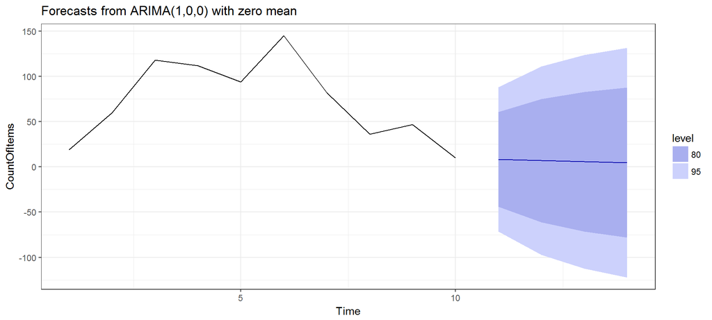

```r
AllItems_TopProduct_1_WeekDELX =
  AllTransactions %>%
  filter(BARCODE == "8901030534898") %>%
  filter(STOREID == "DEL0000000005")  %>%
  group_by(CREATED_STAMP_Week) %>%
  tally()

CountOfItems = ts(AllItems_TopProduct_1_WeekDELX$n)

fit = auto.arima(CountOfItems,stepwise=FALSE, approximation=FALSE)

predictions = fit %>% forecast(h=4)

predictions %>% autoplot(include=10) +theme_bw()
```

The predictions for Weeks 14, 15, 16 and 17 using ARIMA are shown here.

|  | Weeks | Predictions |
| --- | --- | --- |
| 1 | Week 14 | 8 |
| 2 | Week 15 | 7 |
| 3 | Week 16 | 6 |
| 4 | Week 17 | 5 |

## 21.2 Forecasting using ETS

The forecasting of the product is done through ETS (Exponential Time Series)

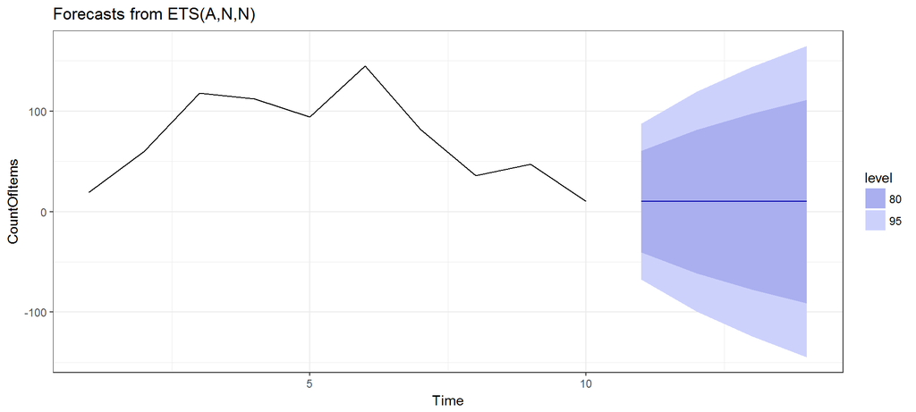

```r
CountOfItems = ts(AllItems_TopProduct_1_WeekDELX$n)

fit = ets(CountOfItems)

predictions = fit %>% forecast(h=4)

predictions %>% autoplot(include=10) +theme_bw()
```

The predictions for Weeks 14, 15, 16 and 17 using ETS are shown here.

|  | Weeks | Predictions |
| --- | --- | --- |
| 1 | Week 14 | 10 |
| 2 | Week 15 | 10 |
| 3 | Week 16 | 10 |
| 4 | Week 17 | 10 |